# Chicago 311 Service Requests

#### Change the type to int & to lower case, respectively

```python
# Changing the 'community areas' datatype of the df dataframe from 'float' to 'int'.

df['community areas'] = df['community areas'].astype('int64')
```

```python
# Update df dataframe with merged results of df dataframe and comm dataframes.

df = pd.merge(df, comm, on="community areas")
```

```python
# Shows the first 5 rows of the df dataframe after merging with the comm dataframe.

df.head()
```

|  | creation date | status | completion date | service request number | type of service request | street address | x coordinate | y coordinate | ward | police district | community area | latitude | longitude | location | historical wards 2003-2015 | zip codes | community areas | census tracts | wards | community area name |
| --- | --- | --- | --- | --- | --- | --- | --- | --- | --- | --- | --- | --- | --- | --- | --- | --- | --- | --- | --- | --- |
| 0 | 12/18/2018 | Completed | 12/19/2018 | 18-03386535 | Graffiti Removal | 5926 W ROSCOE ST | 1.136269e+06 | 1.921998e+06 | 36.0 | 16.0 | 15.0 | 41.942238 | -87.775029 | (41.942237800177, -87.77502930646) | 25.0 | 22254.0 | 15 | 342.0 | 44.0 | Portage Park |
| 1 | 12/18/2018 | Completed | 12/19/2018 | 18-03388557 | Graffiti Removal | 5600 W LAWRENCE AVE | 1.138135e+06 | 1.931358e+06 | 45.0 | 16.0 | 15.0 | 41.967891 | -87.767602 | (41.967890500498, -87.767602295606) | 20.0 | 21869.0 | 15 | 94.0 | 50.0 | Portage Park |
| 2 | 12/17/2018 | Open | NaN | 18-03378468 | Graffiti Removal | 4024 N MEADE AVE | 1.134970e+06 | 1.926124e+06 | 38.0 | 16.0 | 15.0 | 41.953749 | -87.779394 | (41.953749432258, -87.779393831589) | 25.0 | 22254.0 | 15 | 131.0 | 19.0 | Portage Park |
| 3 | 12/17/2018 | Completed | 12/20/2018 | 18-03379631 | Graffiti Removal | 5117 W MONTROSE AVE | 1.141552e+06 | 1.928773e+06 | 45.0 | 16.0 | 15.0 | 41.960516 | -87.755218 | (41.960516074326, -87.755218076836) | 20.0 | 22618.0 | 15 | 259.0 | 50.0 | Portage Park |
| 4 | 12/17/2018 | Completed | 12/20/2018 | 18-03378815 | Graffiti Removal | 4800 W ADDISON ST | 1.143740e+06 | 1.923503e+06 | 30.0 | 16.0 | 15.0 | 41.946232 | -87.747198 | (41.946231828075, -87.747197692752) | 25.0 | 22618.0 | 15 | 360.0 | 21.0 | Portage Park |

### Analysis / Visualization

#### By service type

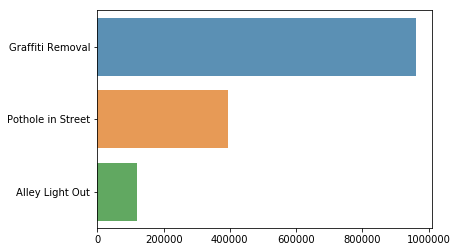

```python
# Refer to Functions section.
# fn: top_value_counts_bar(dataframe, list of columns).
# Creating a barplot with upto 10 unique variables that have the most counts in 'type of service request'.
# When there are less than 10 unique variables, creates a bar plot with existing variables.

top_value_counts_bar(df, "type of service request")
```

```python
# Counts of each status (completed, opened).

df['status'].value_counts()
```

```
Completed    1470397
Open            7218
Name: status, dtype: int64
```

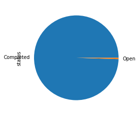

```python
# Create a piechart of 'status' column in the df dataframe.

df['status'].value_counts().plot(kind='pie');
```

#### By neighborhood - barplot using seaborn

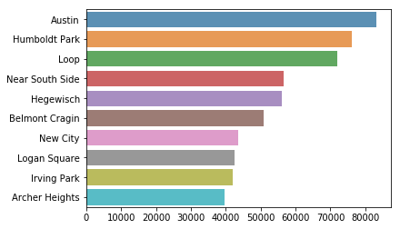

```python
# Refer to Functions section.
# fn: top_value_counts_bar(dataframe, list of columns).

# Creating a barplot with 10 unique variables that have the most counts in 'community area name'.

top_value_counts_bar(df, "community area name")
```

#### By Time

```
* pandas.to_datetime(arg, errors='raise', format)
: Converts columns in a DataFrame type to datetime format.

-> Input:
    (1) arg: (Series)
    (2) errors: 'ignore', 'raise', 'coerce'; default is 'raise'.
        - If 'coerce', invalid parsing will be set as NaT.
        - If 'raise', invalid parsing will raise an exception.
        - If 'ignore', invalid parsing will return the originial input.
    (3) format: (str) format for the resulting datetime type; default is None.
        i.e. "%m/%d/%Y"

c.f. Can also use .astype('datetime64')

(Note) other types can be used for 'arg'.

* pandas.Series.dt
: Accessor object for datetimelike properties of the Series values.

* pandas.Series.dt.weekday
: Returns the day of the week with Monday = 0, Sunday = 6.

* pandas.Series.dt.day_name
: Returns the name of the day of the week.

- Some features:
pandas.Series.dt.year - Returns the year of the date time.
pandas.Series.dt.month - Returns the month of the date time.
pandas.Series.dt.day - Returns the day of the date time.
pandas.Series.dt.hour - Returns the hour of the date time.
pandas.Series.dt.minute - Returns the minute of the date time.

(Note)
: pandas.Series has to be in 'datetime' type.
```

- More about to_datetime(): https://pandas.pydata.org/pandas-docs/stable/reference/api/pandas.to_datetime.html
- More about datetime format(): https://docs.python.org/3/library/datetime.html#strftime-and-strptime-behavior

##### Converts to the datetime type

```python
# Check datatypes for 'creation date' and 'completion date' columns.

print(df['creation date'].dtype)
print(df['completion date'].dtype)
```

```
object
object
```

```python
# Converts 'creation date' and 'completion date' to datetime types.
# Coerce the errors for completion date as there are NaN values.

df['creation date'] = pd.to_datetime(df['creation date'], format = '%m/%d/%Y')
df['completion date'] = pd.to_datetime(df['completion date'],errors = 'coerce', format = '%m/%d/%Y')
```

```python
# Create new columns that has day information for the creation date and completion date.
# And create new columns that have month and year information for the creation date.

df['creation day'] = df['creation date'].dt.weekday_name
df['completion day'] = df['completion date'].dt.weekday_name
df['creation_month'] = pd.DatetimeIndex(df['creation date']).month
df['creation_year'] = pd.DatetimeIndex(df['creation date']).year
```

```python
# Shows the first 5 rows of newly created datetime related columns of the df dataframe.

df[['creation day', 'completion day', 'creation_month', 'creation_year']].head()
```

|  | creation day | completion day | creation_month | creation_year |
| --- | --- | --- | --- | --- |
| 0 | Tuesday | Wednesday | 12 | 2018 |
| 1 | Tuesday | Wednesday | 12 | 2018 |
| 2 | Monday | NaN | 12 | 2018 |
| 3 | Monday | Thursday | 12 | 2018 |
| 4 | Monday | Thursday | 12 | 2018 |

#### By 'month' - 'type of service request', barplot with matplotlib with custom colors

```
* pandas.crosstab(index, columns)
: Builds a cross-tabulation table, computing a frequency table as a default.

-> Input:
    (1) index: (array-like, Series, list of array/Series) values to group by in the rows

    (2) columns: (array-like, Series, list of array/Series) values to group by in the columns
```

- More about crosstab(): https://pandas.pydata.org/pandas-docs/stable/reference/api/pandas.crosstab.html

```python
# df.groupby(['creation_month', 'type of service request']).count()['creation date']
```

```python
# Creats a crosstab table by creation_month and type of service request.
# Counting the number of observations by month and service types.

pd.crosstab(df['creation_month'],df['type of service request'])
```

| type of service request creation_month | Alley Light Out | Graffiti Removal | Pothole in Street |
| --- | --- | --- | --- |
| 1 | 8243 | 78679 | 43383 |
| 2 | 10548 | 77100 | 52612 |
| 3 | 11447 | 87641 | 65861 |
| 4 | 9558 | 83429 | 53140 |
| 5 | 8916 | 84106 | 39057 |
| 6 | 9366 | 79048 | 30237 |
| 7 | 9683 | 78177 | 24302 |
| 8 | 10567 | 85932 | 20251 |
| 9 | 11360 | 78516 | 16689 |
| 10 | 12241 | 83383 | 16891 |
| 11 | 10783 | 76044 | 13168 |
| 12 | 8507 | 70628 | 18122 |

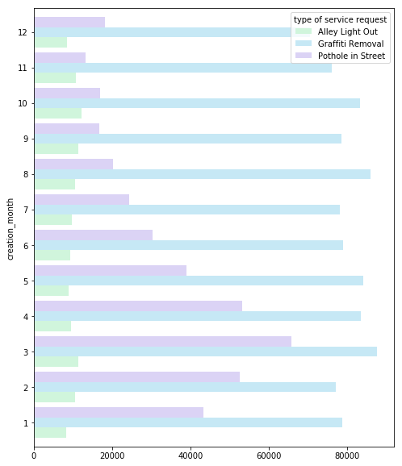

```python
# Creates a horizontal barplot of crosstab results using matplotlib.
# Crosstab of by creation month and type of service request.

# 'barh' creates a horizontal barplot and chose a list of colors.

pd.crosstab(df['creation_month'],df['type of service request']).plot(kind='barh', figsize=(8, 10),
                                                                 color=['#d0f5dc', '#c6e8f5',
                                                                        '#dbd3f5', '#faf3b9']
                                                                , zorder=2, width=0.85);
```

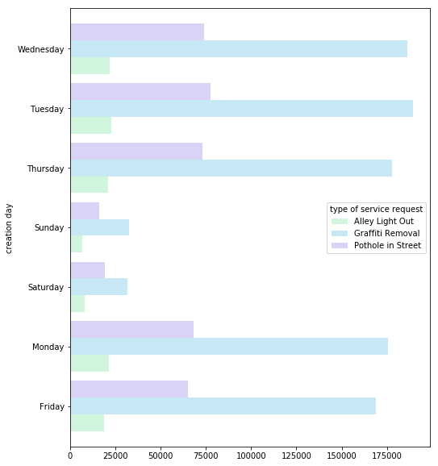

```python
# Creates a horizontal barplot of crosstab results using matplotlib.
# Crosstab of by creation day and type of service request.

# 'barh' creates a horizontal barplot and chose a list of colors.

ax = pd.crosstab(df['creation day'],df['type of service request']).plot(kind='barh', figsize=(8, 10),
                                                                 color=['#d0f5dc', '#c6e8f5',
                                                                        '#dbd3f5', '#faf3b9']
                                                                , zorder=2, width=0.85)
```

#### By Duration

```
* pandas.groupby().size()
: For the groupby result, size() computes the group sizes.


* DataFrame[condition]
: Filters the dataframe by the given condition provided inside '[]'.

(Example)
DataFrame[DataFrame['column1']=='A'] will filter and select rows of the dataframe where the value for the 'column1' is 'A'.
```

##### Creating new column with datetime columns

```python
# Creates a 'response time' column using the difference between the 'creation date' and 'completion date'.

df['response time'] = df['completion date'] - df['creation date']
```

```python
# Checking NaN values for 'response time' column; correponds to the number of missing values in ;completion date; column.

df['response time'].isnull().sum()
```

```
7218
```

```python
# Shows the 5 largest values of 'response time'.

df['response time'].value_counts().nlargest()
```

```
0 days    586531
1 days    241430
2 days     78653
3 days     73111
4 days     47725
Name: response time, dtype: int64
```

```python
# Group by with two columns.
# First grouping by the 'type of service request'
# Then within each type of service request, grouping by the 'response time'.
# Result shows the size of each response time for each type of service request.

# Shows the first 5 rows of the result.

df.groupby(['type of service request', 'response time']).size().head()
```

```
type of service request  response time
Alley Light Out          0 days           9550
                         1 days           6728
                         2 days           4472
                         3 days           3546
                         4 days           3072
dtype: int64
```

##### Creating a new dataframe with value_counts() result, pandas Series object

```python
# Creates a new dataframe with value_counts result (pandas.Series) of selected information.

# df[df['type of service request']=='Alley Light Out']: Filter the dataframe where the type of service request
# is Alley Light Out only. Then count the unique values of response time for the Alley Light Out service request.

# Shows the first 11 rows for the dataframe by slicing the dataframe with [:11].

alley_response = df[df['type of service request']=='Alley Light Out']['response time'].value_counts()
alley_df = pd.DataFrame(alley_response)
alley_df[:11]
```

|  | response time |
| --- | --- |
| 0 days | 9550 |
| 1 days | 6728 |
| 2 days | 4472 |
| 3 days | 3546 |
| 4 days | 3072 |
| 7 days | 2952 |
| 5 days | 2751 |
| 6 days | 2711 |
| 8 days | 2467 |
| 9 days | 1978 |
| 14 days | 1886 |

##### Finds avg response time by service request type - timeline(month) plot using matplotlib

```
* DataFrame.unstack()
: With unstack method, index values will become column names.
```

- Example

[figure not shown]

  </br>
- More about unstack(): https://pandas.pydata.org/pandas-docs/stable/reference/api/pandas.DataFrame.unstack.html

```python
# Shows the first 5 rows of the 'response time' column.

df['response time'].head()
```

```
0   1 days
1   1 days
2      NaT
3   3 days
4   3 days
Name: response time, dtype: timedelta64[ns]
```

```python
# Check the data type of 'response time' column.

df['response time'].dtypes
```

```
dtype('<m8[ns]')
```

```python
# As the column is in datetime type, using the dt accessor, converts to the day type
# and set it as a 'days took for response' column.

df['days took for response'] = df['response time'].dt.days
```

##### Mean days took for response by the type of service request

```python
# Describes a statistics of a group by result that groups 'days took for response'
# by 'type of service request'.

df['days took for response'].groupby(df['type of service request']).describe()
```

| type of service request | count | mean | std | min | 25% | 50% | 75% | max |
| --- | --- | --- | --- | --- | --- | --- | --- | --- |
| Alley Light Out | 117773.0 | 49.479185 | 75.255288 | 0.0 | 5.0 | 23.0 | 66.0 | 6107.0 |
| Graffiti Removal | 962540.0 | 4.901327 | 239.176771 | 0.0 | 0.0 | 0.0 | 2.0 | 32275.0 |
| Pothole in Street | 390084.0 | 19.883971 | 33.228188 | 0.0 | 1.0 | 6.0 | 22.0 | 997.0 |

##### Mean days took for response by the service type requested and by the month

```python
# First grouping by the 'creation month'.
# Then within each type of service request, grouping by the 'type of service request'.
# Get mean values for all columns with mean() aggregation function.
# Select mean values information for the 'datys took for response'.

df.groupby(['creation_month','type of service request']).mean()['days took for response']
```

```
creation_month  type of service request
1               Alley Light Out            49.834426
                Graffiti Removal           20.290205
                Pothole in Street           7.338612
2               Alley Light Out            44.970697
                Graffiti Removal           12.126563
                Pothole in Street          10.222972
3               Alley Light Out            45.374092
                Graffiti Removal            3.578713
                Pothole in Street          13.462154
4               Alley Light Out            46.475790
                Graffiti Removal            2.980630
                Pothole in Street          22.902405
5               Alley Light Out            52.436701
                Graffiti Removal            2.616888
                Pothole in Street          32.679524
6               Alley Light Out            58.570920
                Graffiti Removal            2.939581
                Pothole in Street          33.611415
7               Alley Light Out            55.584953
                Graffiti Removal            3.200276
                Pothole in Street          33.510227
8               Alley Light Out            52.799768
                Graffiti Removal            2.890274
                Pothole in Street          31.182469
9               Alley Light Out            46.950023
                Graffiti Removal            2.295659
                Pothole in Street          28.796420
10              Alley Light Out            46.448804
                Graffiti Removal            1.965964
                Pothole in Street          21.636937
11              Alley Light Out            49.468553
                Graffiti Removal            1.765215
                Pothole in Street          13.555600
12              Alley Light Out            46.865012
                Graffiti Removal            2.761041
                Pothole in Street           6.129410
Name: days took for response, dtype: float64
```

```python
# Above contains multiindex, unstack() is needed to plot the desired result; one line per each type of service request.

df.groupby(['creation_month','type of service request']).mean()['days took for response'].index
```

```
MultiIndex(levels=[[1, 2, 3, 4, 5, 6, 7, 8, 9, 10, 11, 12], ['Alley Light Out', 'Graffiti Removal', 'Pothole in Street']],
           labels=[[0, 0, 0, 1, 1, 1, 2, 2, 2, 3, 3, 3, 4, 4, 4, 5, 5, 5, 6, 6, 6, 7, 7, 7, 8, 8, 8, 9, 9, 9, 10, 10, 10, 11, 11, 11], [0, 1, 2, 0, 1, 2, 0, 1, 2, 0, 1, 2, 0, 1, 2, 0, 1, 2, 0, 1, 2, 0, 1, 2, 0, 1, 2, 0, 1, 2, 0, 1, 2, 0, 1, 2]],
           names=['creation_month', 'type of service request'])
```

```python
# With unstack(), type of service request will become columns-like.

df.groupby(['creation_month','type of service request']).mean()['days took for response'].unstack()
```

| type of service request creation_month | Alley Light Out | Graffiti Removal | Pothole in Street |
| --- | --- | --- | --- |
| 1 | 49.834426 | 20.290205 | 7.338612 |
| 2 | 44.970697 | 12.126563 | 10.222972 |
| 3 | 45.374092 | 3.578713 | 13.462154 |
| 4 | 46.475790 | 2.980630 | 22.902405 |
| 5 | 52.436701 | 2.616888 | 32.679524 |
| 6 | 58.570920 | 2.939581 | 33.611415 |
| 7 | 55.584953 | 3.200276 | 33.510227 |
| 8 | 52.799768 | 2.890274 | 31.182469 |
| 9 | 46.950023 | 2.295659 | 28.796420 |
| 10 | 46.448804 | 1.965964 | 21.636937 |
| 11 | 49.468553 | 1.765215 | 13.555600 |
| 12 | 46.865012 | 2.761041 | 6.129410 |

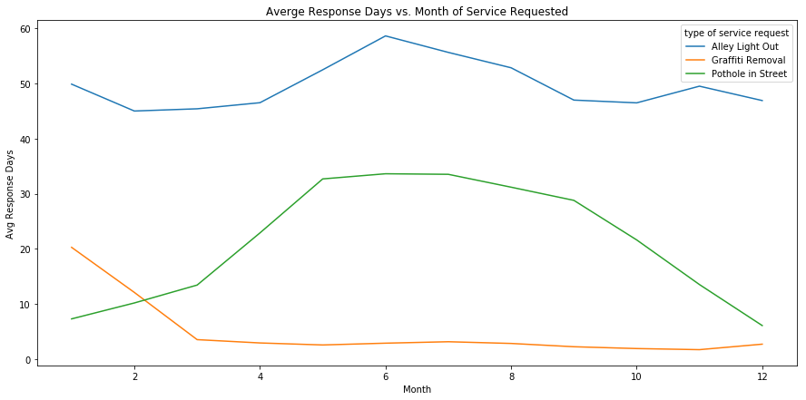

```python
# Creates a figure and axes object with matplotlib
fig, ax = plt.subplots(figsize=(15,7))
# Prepares the data for the plot
# Grouping the dataset by the creation month and within the creation month grouping by the type of service request
# Get mean days took for response for the grouped by series and unstack the result to plot by each type of service request.
df.groupby(['creation_month','type of service request']).mean()['days took for response'].unstack().plot(ax=ax)
ax.set_xlabel('Month')
ax.set_ylabel('Avg Response Days')
ax.set_title('Averge Response Days vs. Month of Service Requested');
```

##### By Neighborhood

```
* DataFrame.loc['column'/list of columns/boolean array]
: Access a group of rwos and columns by label(s) or a boolean array.

(Example) DataFrame.loc[:, ['col1', 'col3']]
: Returns the values present in the 'col1' and 'col3' columns of the dataframe.
```

- More about .loc: https://pandas.pydata.org/pandas-docs/stable/reference/api/pandas.DataFrame.loc.html

```python
# Counting the number of observations by community area name and service types.

by_comm_area = pd.crosstab(df['community area name'],df['type of service request'])
by_comm_area.head()
```

| type of service request community area name | Alley Light Out | Graffiti Removal | Pothole in Street |
| --- | --- | --- | --- |
| Albany Park | 1532 | 24425 | 4768 |
| Archer Heights | 1649 | 29995 | 8083 |
| Armour Square | 159 | 3538 | 2070 |
| Ashburn | 3553 | 1798 | 8205 |
| Auburn Gresham | 1309 | 730 | 5985 |

```python
# Unstack the above to have multi-index levels; type of service request - community area names.
# This step is needed to select a subset of data by the community area names.
# Shows the first 5 rows of the unstacked result.

by_comm_area.unstack().head()
```

```
type of service request  community area name
Alley Light Out          Albany Park            1532
                         Archer Heights         1649
                         Armour Square           159
                         Ashburn                3553
                         Auburn Gresham         1309
dtype: int64
```

```python
# Create a new dataframe with selected community area names, 'Hyde Park', 'Near North Side', 'Ohare'.
# ':,' inside the loc indicates that it will show the entire column data for selected community area naeme.
# ':' <=> slice(None)

select_areas = pd.DataFrame(by_comm_area.unstack().loc[:, ['Hyde Park', 'Near North Side', 'Ohare']])
select_areas
```

| type of service request | community area name | 0 |
| --- | --- | --- |
| Alley Light Out | Hyde Park | 1149 |
|  | Near North Side | 368 |
|  | Ohare | 1294 |
| Graffiti Removal | Hyde Park | 313 |
|  | Near North Side | 1553 |
|  | Ohare | 11825 |
| Pothole in Street | Hyde Park | 2692 |
|  | Near North Side | 3130 |
|  | Ohare | 5013 |

#### Hyde Park - pieplot using matplotlib

```python
# Check number of service requested in Hyde Park by each service type.

by_comm_area.loc['Hyde Park']
```

```
type of service request
Alley Light Out      1149
Graffiti Removal      313
Pothole in Street    2692
Name: Hyde Park, dtype: int64
```

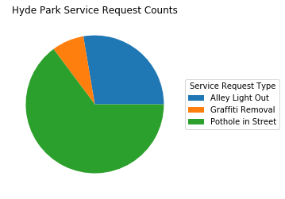

```python
# Gets a list of values,number of requests, of the Hyde Park.
counts = by_comm_area.loc['Hyde Park'].values
# Gets a list of type of service requests.
services = by_comm_area.loc['Hyde Park'].index

# Initializes the fig and axes.
fig, ax = plt.subplots()
wedges = ax.pie(counts)
ax.legend(services, title="Service Request Type", loc="center left",bbox_to_anchor=(1, 0, 0.5, 1))
ax.set_title("Hyde Park Service Request Counts");
```

#### By Response Time

```
* DataFrame.sort_values(by)
: Sort by the specified values. Default is ascending and row-wise(index).

-> Input:
        by: (str / list of str) Name(s) to be used to sort by.

   Output: (DataFrame) Sorted dataframe.
```

- More about sort_values(): https://pandas.pydata.org/pandas-docs/stable/reference/api/pandas.DataFrame.sort_values.html

```python
# Creates a new dataframe of mean 'days took for response' by 'community area name'
# When creating a dataframe, rename the column 'days took for response' to 'avg response time' using .rename().

mean_resp_by_area = pd.DataFrame(df['days took for response'].rename('avg response time').\
                        groupby(df['community area name']).mean())

# Shows the first 5 rows of a created dataframe.
mean_resp_by_area.head()
```

| community area name | avg response time |
| --- | --- |
| Albany Park | 13.943987 |
| Archer Heights | 8.613573 |
| Armour Square | 9.109116 |
| Ashburn | 24.582177 |
| Auburn Gresham | 22.545888 |

```python
# Shows the 10 shortest avg response time.

mean_resp_by_area.sort_values(by=['avg response time'])[:10]
```

| community area name | avg response time |
| --- | --- |
| Grand Boulevard | 4.624931 |
| Garfield Ridge | 5.419526 |
| Riverdale | 5.768887 |
| Brighton Park | 5.923474 |
| Near South Side | 6.056100 |
| Bridgeport | 6.264906 |
| Hegewisch | 6.506137 |
| Fuller Park | 7.064787 |
| Humboldt Park | 7.258746 |
| Austin | 7.507015 |

```python
# Shows the 10 longest avg response time.

mean_resp_by_area.sort_values(by=['avg response time'])[-10:]
```

| community area name | avg response time |
| --- | --- |
| Beverly | 23.939337 |
| West Englewood | 24.208770 |
| Ashburn | 24.582177 |
| West Garfield Park | 24.839179 |
| Washington Park | 25.702689 |
| East Garfield Park | 26.740464 |
| Chicago Lawn | 27.633468 |
| Oakland | 27.982151 |
| Forest Glen | 28.396794 |
| Edgewater | 29.777219 |

### Possible Questions

- Given the address, probability of getting a service request?
- Comparing two areas, which area has more chances to get a certain service request?
- What is the possibility to get each service on Monday? in December?
- Predicting the response time: y(reponse time) = features(service type, area, month, day, year + features from census data)

### Functions

```python
def check_values_by_column(data, columns):
    '''
    Prints values for the given list of columns in the DataFrame.

    Input:
        data - (DataFrame)
        columns - (list) a list of columns of the DataFrame

    '''
    for col in columns:
        print("Column: ", col)
        print("has ", data[col].nunique(), "unique value(s).")
        print("=>",data[col].unique())
        print("\n")

    return None
```

```python
def print_columns(data, name):
    '''
    Returns a DataFrame of column names of a given DataFrame.

    Input:
        data - (DataFrame)
        name - (str) name for the column
    '''

    return pd.DataFrame(list(data.columns), columns=[name])
```

```python
def top_value_counts_bar(data, col, n_limit=10):
    '''
    Creates a barplot of n largest values of a column using seaborn.

    Input:
        data - (DataFrame)
        col - (str) specify the column name that will be used
        n_limit - (int, default=10) number for specifying the top 'n' values
    '''

    top10_count  = pd.value_counts(data[col]).nlargest(n_limit)
    sns.barplot(top10_count.values, top10_count.index, alpha=0.8)
```